# PracticalMachineLearningProject_March2015

Luis M78

Saturday, March 21, 2015

For this project, it is very important to remove features that do not matter for the classification problem. First it is necesarry to remove data columns not needed, the str function is used to have a glimpse of the variables contents, like shown below. Variables that appear not to be measurements are removed.

```r
setwd("C:/Users/Luis Miguel/Dropbox/Data Specialization JHU/PracticalMachineLearning/Final_project_Machine")
data_training <- read.csv("pml-training.csv",na.strings="NA")
str(data_training)
```

```
## 'data.frame':    19622 obs. of  160 variables:
##  $ X                       : int  1 2 3 4 5 6 7 8 9 10 ...
##  $ user_name               : Factor w/ 6 levels "adelmo","carlitos",..: 2 2 2 2 2 2 2 2 2 2 ...
##  $ raw_timestamp_part_1    : int  1323084231 1323084231 1323084231 1323084232 1323084232 1323084232 1323084232 1323084232 1323084232 1323084232 ...
##  $ raw_timestamp_part_2    : int  788290 808298 820366 120339 196328 304277 368296 440390 484323 484434 ...
##  $ cvtd_timestamp          : Factor w/ 20 levels "02/12/2011 13:32",..: 9 9 9 9 9 9 9 9 9 9 ...
##  $ new_window              : Factor w/ 2 levels "no","yes": 1 1 1 1 1 1 1 1 1 1 ...
##  $ num_window              : int  11 11 11 12 12 12 12 12 12 12 ...
##  $ roll_belt               : num  1.41 1.41 1.42 1.48 1.48 1.45 1.42 1.42 1.43 1.45 ...
##  $ pitch_belt              : num  8.07 8.07 8.07 8.05 8.07 8.06 8.09 8.13 8.16 8.17 ...
##  $ yaw_belt                : num  -94.4 -94.4 -94.4 -94.4 -94.4 -94.4 -94.4 -94.4 -94.4 -94.4 ...
##  $ total_accel_belt        : int  3 3 3 3 3 3 3 3 3 3 ...
##  $ kurtosis_roll_belt      : Factor w/ 397 levels "","-0.016850",..: 1 1 1 1 1 1 1 1 1 1 ...
##  $ kurtosis_picth_belt     : Factor w/ 317 levels "","-0.021887",..: 1 1 1 1 1 1 1 1 1 1 ...
##  $ kurtosis_yaw_belt       : Factor w/ 2 levels "","#DIV/0!": 1 1 1 1 1 1 1 1 1 1 ...
```

[output cut: 86 more lines]

```r
removecolumns <- c("X","user_name","raw_timestamp_part_2","cvtd_timestamp","new_window","num_window")
```

Then, after defining a vector with the columns that are not neded we remove it like so

```r
data_training2 <- data_training[,-c(as.factor(removecolumns))]
data_training2$num_window <- NULL
columns <- dim(data_training2)[2]
```

The new data set has 153 columns. Now we load the caret package, and we will remove variables that have near zero variance. Also columns that have a lot of NAs

```r
library(caret)
nzv <- nearZeroVar(data_training2)
filteredTraining <- data_training2[,-nzv]
dim(filteredTraining)[2]
```

```
## [1] 94
```

```r
# now there are 94
filteredTraining2 <-filteredTraining[ , colSums(is.na(filteredTraining)) <= nrow(filteredTraining)*0.5]
columnsb <- dim(filteredTraining2)[2]
```

Now we have 53 columns. THe computer will need less memory and time to fit the machine learning models. Now we proceed to split the training data into traning and test set. Also helps in the processing because there are less entries.

```r
set.seed(3000)
inTrain <- createDataPartition(y=filteredTraining2$classe,p=0.75,list=FALSE)

training <- filteredTraining2[inTrain,]
testing <-  filteredTraining2[-inTrain,]

dim(training)
```

```
## [1] 14718    53
```

```r
dim(testing)
```

```
## [1] 4904   53
```

Now we proceed to fit the models. I am also timing the models for comparision

```r
ptm <- proc.time()
set.seed(3000)
myControl <- trainControl(method='cv',number=2,repeats=2,verboseIter = TRUE)
modelFit <- train(classe~.,method="rf",data=training,ntrees=100, trControl=myControl)
summary(modelFit$finalModel)
```

```
##                 Length Class      Mode
## call                5  -none-     call
## type                1  -none-     character
## predicted       14718  factor     numeric
## err.rate         3000  -none-     numeric
## confusion          30  -none-     numeric
## votes           73590  matrix     numeric
## oob.times       14718  -none-     numeric
## classes             5  -none-     character
## importance         52  -none-     numeric
## importanceSD        0  -none-     NULL
## localImportance     0  -none-     NULL
## proximity           0  -none-     NULL
## ntree               1  -none-     numeric
## mtry                1  -none-     numeric
## forest             14  -none-     list
## y               14718  factor     numeric
## test                0  -none-     NULL
## inbag               0  -none-     NULL
## xNames             52  -none-     character
## problemType         1  -none-     character
## tuneValue           1  data.frame list
## obsLevels           5  -none-     character
```

```r
print(modelFit)
```

```
## Random Forest
##
## 14718 samples
##    52 predictor
##     5 classes: 'A', 'B', 'C', 'D', 'E'
##
## No pre-processing
## Resampling: Cross-Validated (2 fold)
##
## Summary of sample sizes: 7360, 7358
##
## Resampling results across tuning parameters:
##
##   mtry  Accuracy   Kappa      Accuracy SD   Kappa SD
##    2    0.9851203  0.9811727  9.894686e-05  0.0001195725
##   27    0.9863432  0.9827223  2.908865e-04  0.0003639473
##   52    0.9800248  0.9747298  3.839655e-03  0.0048587796
##
## Accuracy was used to select the optimal model using  the largest value.
## The final value used for the model was mtry = 27.
```

```r
t1 <- proc.time()-ptm
```

The model required 762.06, 4.76, 833.26, NA, NA seconds to process. I am working with an old laptop with 3gb of RAM and an intel processor T5450. In my office work desktop PC the model took much less time. Now we list and plot the variables importance for the model

```r
varImp(modelFit,scale=FALSE)
```

```
## rf variable importance
##
##   only 20 most important variables shown (out of 52)
##
##                      Overall
## roll_belt             1524.8
## pitch_forearm          904.1
## yaw_belt               830.3
## roll_forearm           678.6
## magnet_dumbbell_y      671.1
## magnet_dumbbell_z      668.3
## pitch_belt             662.8
## accel_dumbbell_y       343.1
## magnet_dumbbell_x      288.9
## roll_dumbbell          281.8
## accel_forearm_x        279.4
## magnet_belt_z          251.9
## magnet_forearm_z       240.0
## accel_dumbbell_z       231.2
## total_accel_dumbbell   219.6
## magnet_belt_y          212.6
## accel_belt_z           205.8
## gyros_belt_z           203.3
## yaw_arm                185.4
## magnet_belt_x          169.1
```

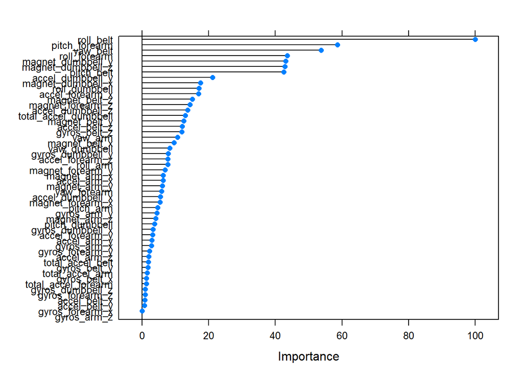

```r
#plotting the variable importance
plot(varImp(modelFit,scale=TRUE))
```

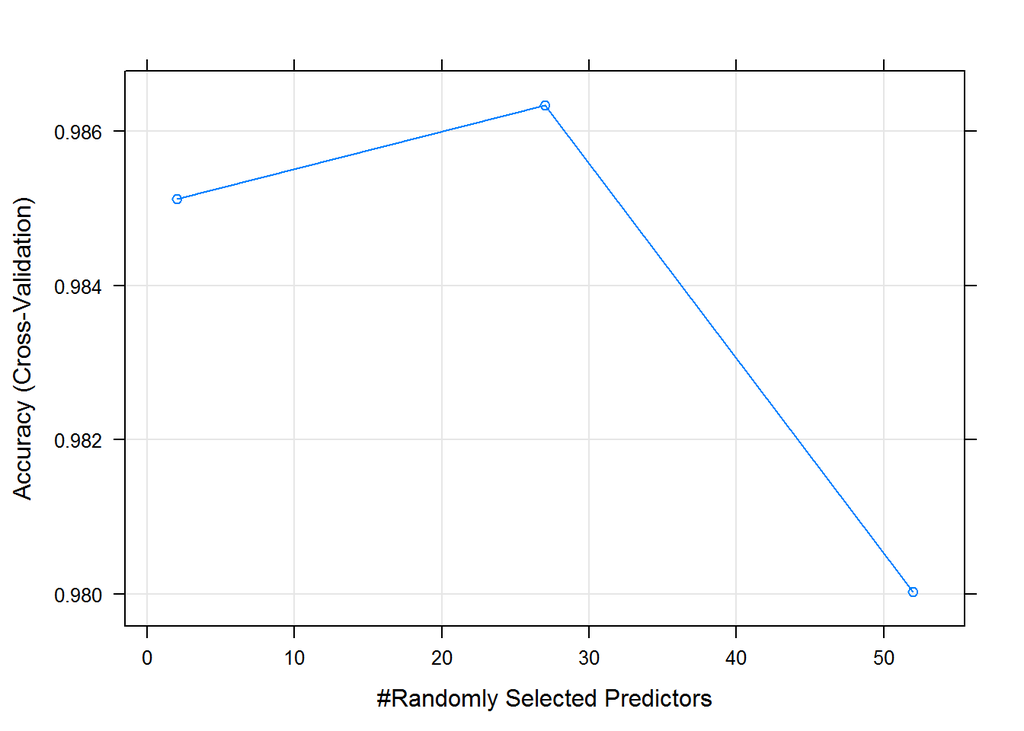

```r
# plotting the  corss validation accuracy
plot(modelFit)
```

Now we test the model with the testing partition from before

```r
dim(testing)
```

```
## [1] 4904   53
```

```r
set.seed(3000)
prediction_1 <-predict(modelFit,newdata=testing)

accuracyper <- sum(testing$class==prediction_1)/dim(testing)[1]*100
```

The accuracy on the test set is 99.367863 Which is very good.

For intra model comparison we weill fit a random forest model using the random forest package.

```r
library(randomForest)
ptm <- proc.time()
set.seed(3000)
modelRandomForest <- randomForest(classe~., data= training,ntree=200)
#modelRandomForest <- randomForest(classe~., data= filteredTraining2,proximity=TRUE)
t2 <-proc.time()-ptm
modelRandomForest
```

```
##
## Call:
##  randomForest(formula = classe ~ ., data = training, ntree = 200)
##                Type of random forest: classification
##                      Number of trees: 200
## No. of variables tried at each split: 7
##
##         OOB estimate of  error rate: 0.52%
## Confusion matrix:
##      A    B    C    D    E  class.error
## A 4181    3    0    0    1 0.0009557945
## B   11 2830    6    1    0 0.0063202247
## C    0   18 2548    1    0 0.0074016362
## D    0    0   27 2383    2 0.0120232172
## E    0    0    1    6 2699 0.0025868441
```

The model took 60.23, 0.38, 66.46, NA, NA seconds to execute. Much faster than the previous model. Here below is a plot of the model

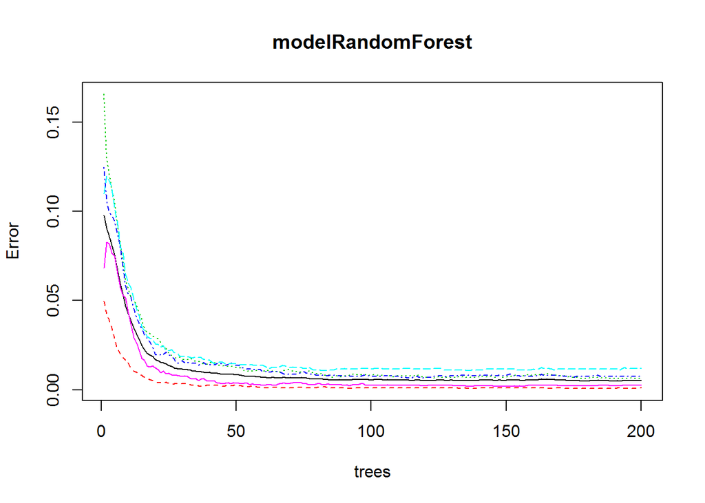

```r
plot(modelRandomForest)
```

Finally a third model is developed

```r
ptm <- proc.time()
set.seed(3000)
myControl <- trainControl(method='cv',number=2,repeats=2,verboseIter = TRUE)
modelGbm <- train(classe~.,method="gbm",data=training,trControl=myControl)
t3 <- proc.time()-ptm
```

This model needed 390.36, 0.67, 394.7, NA, NA seconds to compute.

Finally we test the last two models in the testing partition set.

```r
set.seed(3000)
prediction_2 <-predict(modelRandomForest,newdata=testing)

accuracyper2 <- sum(testing$class==prediction_2)/dim(testing)[1]*100
# 100 % accuracy
set.seed(3000)
prediction_3 <-predict(modelGbm,newdata=testing)

accuracyper3 <-sum(testing$class==prediction_3)/dim(testing)[1]*100
# 96.207 % accuracy
```

Finally we compare the models predictions wih the small test set given by the professor for submission online.

```r
testing2 <- read.csv("pml-testing.csv",na.strings="NA")
# Predicting with the 3 models
predictions1a <- predict(modelFit, newdata=testing2)
predictions2a <- predict(modelRandomForest, newdata=testing2)
predictions3a <- predict(modelGbm , newdata=testing2)

# comparing the predictions among themselves

sum(predictions2a == predictions1a) # The two predictions are the same
```

```
## [1] 20
```

```r
sum(predictions3a == predictions1a)
```

```
## [1] 20
```

THen we write the separate answers using the script provided

```r
results <- as.vector(predictions3a)

pml_write_files = function(x) {
        n = length(x)
        for (i in 1:n) {
                filename = paste0("problem_id_", i, ".txt")
                write.table(x[i], file = filename, quote = FALSE, row.names = FALSE,
                            col.names = FALSE)
        }
}

pml_write_files(results)
```